# 2012 Federal Election Commission Database

```r
library(tidyverse)
```

## Loading the data

```r
fec <- read_csv("datasets/fec/P00000001-ALL.csv")
```

We can add another column to report if the candidate is a Republican or Democrat. In order to do that, we will simply add `"Democrat"` to every Barack Obama entry, and `"Republican"` to all the others.

```r
fec <- fec %>%
    mutate(party = case_when(cand_nm == "Obama, Barack" ~ "Democrat",
                             TRUE ~ "Republican"))
```

Let’s restrict the dataset to only positive contributions, removing refunds.

```r
fec <- fec %>%
    filter(contb_receipt_amt > 0)
```

## Donation statistics by Occupation and Employer

Let’s see if there is any trend of donations amount based on donators occupation and employer.

```r
fec %>% group_by(contbr_occupation) %>% summarise(count = n()) %>% arrange(desc(count))
```

| contbr_occupation | count |
| --- | --- |
| RETIRED | 233990 |
| INFORMATION REQUESTED | 35107 |
| ATTORNEY | 34286 |
| HOMEMAKER | 29931 |
| PHYSICIAN | 23432 |
| INFORMATION REQUESTED PER BEST EFFORTS | 21138 |
| ENGINEER | 14334 |
| TEACHER | 13991 |
| CONSULTANT | 13273 |
| PROFESSOR | 12555 |

[output cut: 990 more lines]

[output not shown]

[output cut: 990 more lines]

We should clean a bit these data, because some of them refer to the same type of employment but are encoded differently.

```r
fec <- fec %>% mutate_if(is_character, str_replace_all, pattern = "INFORMATION REQUESTED PER BEST EFFORTS", replacement = "NOT PROVIDED")
fec <- fec %>% mutate_if(is_character, str_replace_all, pattern = "INFORMATION REQUESTED", replacement = "NOT PROVIDED")
fec <- fec %>% mutate_if(is_character, str_replace_all, pattern = "INFORMATION REQUESTED (BEST EFFORTS)", replacement = "NOT PROVIDED")
fec <- fec %>% mutate_if(is_character, str_replace_all, pattern = "^NONE$", replacement = "NOT PROVIDED")
fec <- fec %>% mutate_if(is_character, str_replace_all, pattern = "^REFUSED$", replacement = "NOT PROVIDED")
fec <- fec %>% mutate_if(is_character, str_replace_all, pattern = "^REQUESTED$", replacement = "NOT PROVIDED")
fec <- fec %>% replace_na(list(contbr_employer = "NOT PROVIDED", contbr_occupation = "NOT PROVIDED"))
fec <- fec %>% mutate_if(is_character, str_replace_all, pattern = "^N/A$", replacement = "NOT PROVIDED")
fec <- fec %>% mutate_if(is_character, str_replace_all, pattern = "^C.E.O.$", replacement = "CEO")
fec <- fec %>% mutate_if(is_character, str_replace_all, pattern = "^RN$", replacement = "REGISTERED NURSE")
fec <- fec %>% mutate_if(is_character, str_replace_all, pattern = "^R.N.$", replacement = "REGISTERED NURSE")
fec <- fec %>% mutate_if(is_character, str_replace_all, pattern = "^UNEMPLOYED$", replacement = "NOT EMPLOYED")
fec <- fec %>% mutate_if(is_character, str_replace_all, pattern = "^SELF$", replacement = "SELF-EMPLOYED")
fec <- fec %>% mutate_if(is_character, str_replace_all, pattern = "SELF EMPLOYED", replacement = "SELF-EMPLOYED")
```

[output not shown]

[output cut: 990 more lines]

[output not shown]

[output cut: 990 more lines]

After this cleaning, let’s create another dataset where we remove all candidates but Barack Obama and Mitt Romney, the main two candidates for this election.

```r
fec_mrbo <- fec %>%
    filter(cand_nm %in% c("Obama, Barack", "Romney, Mitt"))
```

Now we can aggregate the data by occupation and party, and further filter it to keep only occupations that donated over $2 million.

```r
by_occupation <- fec %>%
    group_by(contbr_occupation, party) %>%
    summarise(donations = sum(contb_receipt_amt))
```

```r
over_2mm <- by_occupation %>%
    filter(donations >= 2000000)
```

Let’s view these data.

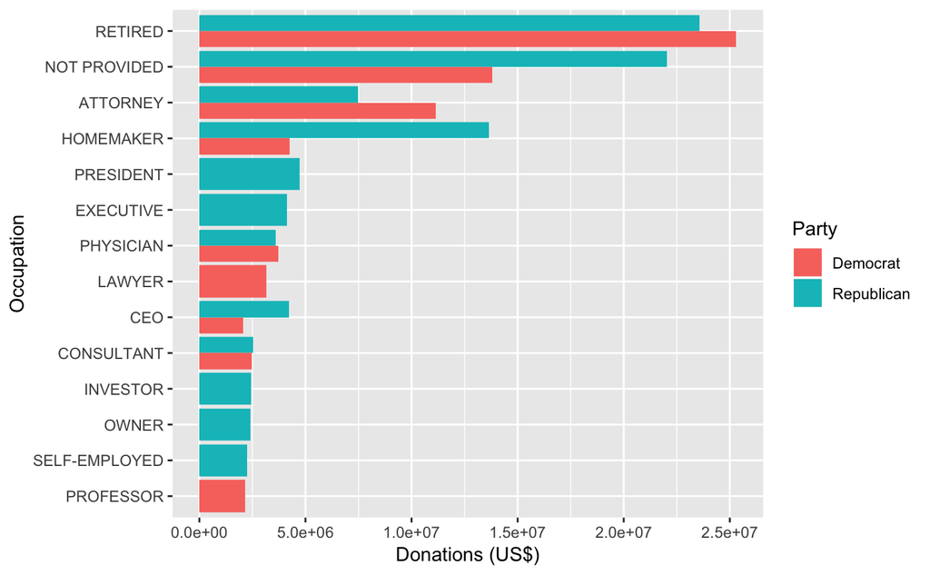

```r
over_2mm %>%
    ggplot(aes(x = reorder(contbr_occupation, donations))) +
    geom_col(aes(y = donations, fill = party), position = "dodge") +
    coord_flip() +
    labs(x = "Occupation", y = "Donations (US$)", fill = "Party")
```

Now we might be interested in aggregating these data by candidate name and occupation or employer, to find the top 10 occupations and employers who donated to the two candidates.

```r
occupation_grouped <- fec_mrbo %>%
    group_by(cand_nm, contbr_occupation) %>%
    summarise(donations = sum(contb_receipt_amt))
top_10_occup <- top_n(occupation_grouped, 10, donations)
```

```r
employer_grouped <- fec_mrbo %>%
    group_by(cand_nm, contbr_employer) %>%
    summarise(donations = sum(contb_receipt_amt))
top_10_empl <- top_n(employer_grouped, 10, donations)
```

Let’s now visualize these two sets.

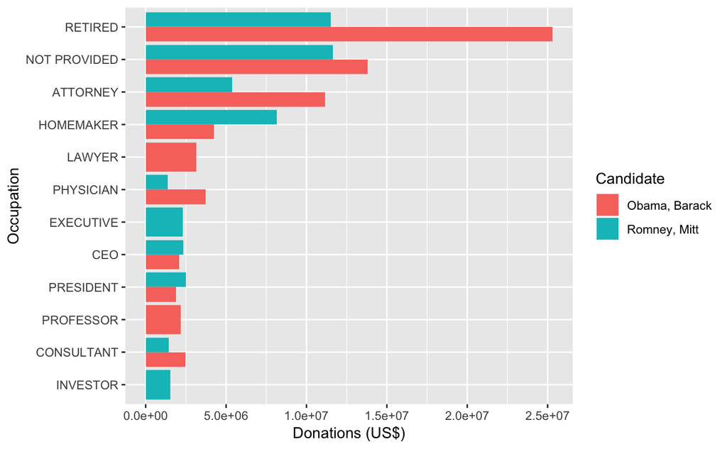

```r
top_10_occup %>%
    ggplot(aes(x = reorder(contbr_occupation, donations))) +
    geom_col(aes(y = donations, fill = cand_nm), position = "dodge") +
    coord_flip() +
    labs(x = "Occupation", y = "Donations (US$)", fill = "Candidate")
```

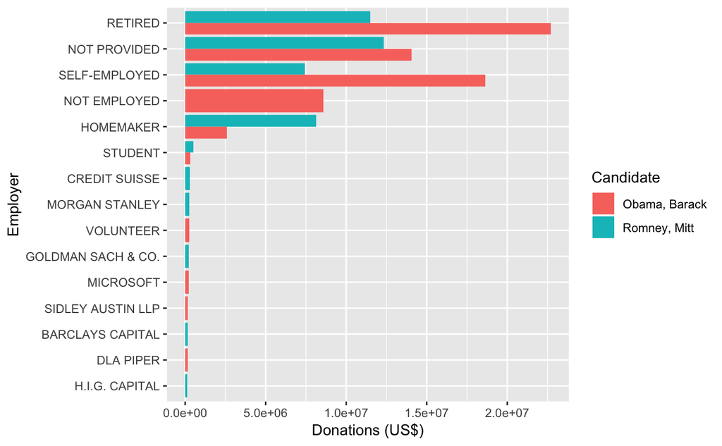

```r
top_10_empl %>%
    ggplot(aes(x = reorder(contbr_employer, donations))) +
    geom_col(aes(y = donations, fill = cand_nm), position = "dodge") +
    coord_flip() +
    labs(x = "Employer", y = "Donations (US$)", fill = "Candidate")
```

## Bucketing donation amounts

We can discretize the contribution amounts into bins describing the contribution size.

```r
fec_mrbo <- fec_mrbo %>%
    mutate(contb_bin = cut(contb_receipt_amt,
                           breaks = c(0, 1, 10, 100, 1000, 10000, 100000, 1000000, 10000000)))
```

Now it is possible to aggregate these data by candidate and contribution bin, to get a histogram by donation size.

```r
contrib_grouped <- fec_mrbo %>%
    group_by(contb_bin, cand_nm) %>%
    summarise(donations = n()) %>%
    mutate(donation_perc = donations / sum(donations))
```

```r
contrib_grouped
```

| contb_bin | cand_nm | donations | donation_perc |
| --- | --- | --- | --- |
| (0,1] | Obama, Barack | 493 | 0.86491228 |
| (0,1] | Romney, Mitt | 77 | 0.13508772 |
| (1,10] | Obama, Barack | 40070 | 0.91586478 |
| (1,10] | Romney, Mitt | 3681 | 0.08413522 |
| (10,100] | Obama, Barack | 372280 | 0.92118189 |
| (10,100] | Romney, Mitt | 31853 | 0.07881811 |
| (100,1e+03] | Obama, Barack | 153991 | 0.78030180 |
| (100,1e+03] | Romney, Mitt | 43357 | 0.21969820 |
| (1e+03,1e+04] | Obama, Barack | 22284 | 0.45974830 |
| (1e+03,1e+04] | Romney, Mitt | 26186 | 0.54025170 |

[output cut: 4 more lines]

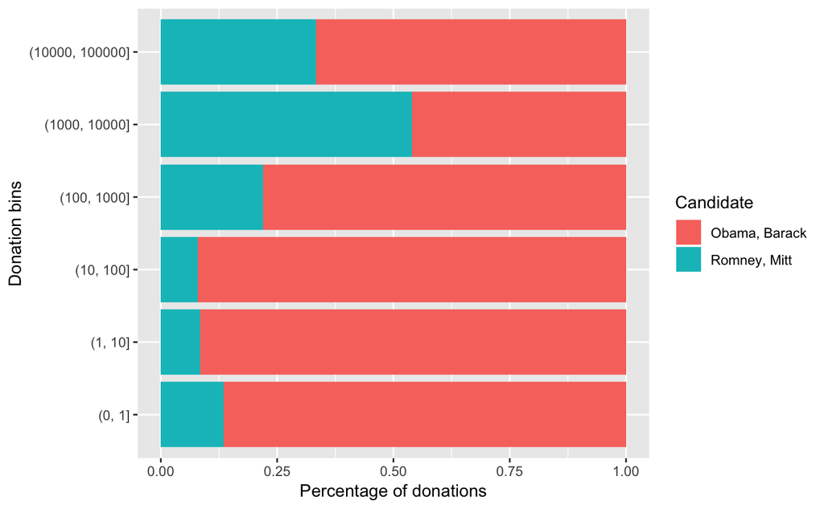

```r
contrib_grouped %>%
    filter(donation_perc != 1.0) %>%
    ggplot(aes(x = contb_bin)) +
    geom_col(aes(y = donation_perc, fill = cand_nm)) +
    coord_flip() +
    labs(x = "Donation bins", y = "Percentage of donations", fill = "Candidate") +
    scale_x_discrete(labels = c("(0, 1]", "(1, 10]", "(10, 100]", "(100, 1000]", "(1000, 10000]", "(10000, 100000]"))
```

## Donation statistics by State

Let’s aggregate the data by candidate name and state.

```r
state_grouped <- fec_mrbo %>%
    group_by(contbr_st, cand_nm) %>%
    summarise(donations = sum(contb_receipt_amt)) %>%
    mutate(donation_perc = donations / sum(donations))
```

[output not shown]

[output cut: 116 more lines]

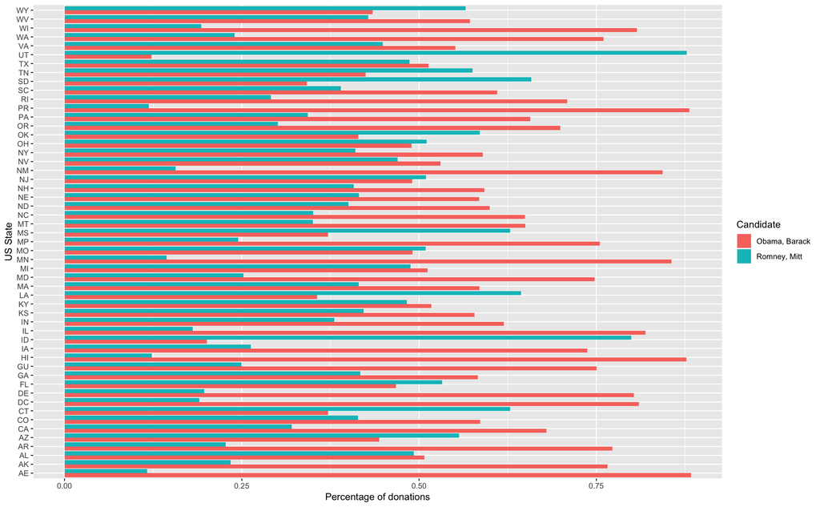

```r
state_grouped %>%
    filter(donation_perc != 1.0, donation_perc >= 0.1, donation_perc <= 0.9) %>%
    ggplot(aes(x = contbr_st)) +
    geom_col(aes(y = donation_perc, fill = cand_nm), position = "dodge") +
    coord_flip() +
    labs(x = "US State", y = "Percentage of donations", fill = "Candidate")
```